# (Ford-GoBike Share)

#### The customer user type has the highest duration all over three types gender, and specifically the highest duration spent as mentioned before belongs to other and female gender type

##### what is the starting hours accompanied with highest duration, and does it confirm the same starting hours we got above with higher duration time ?

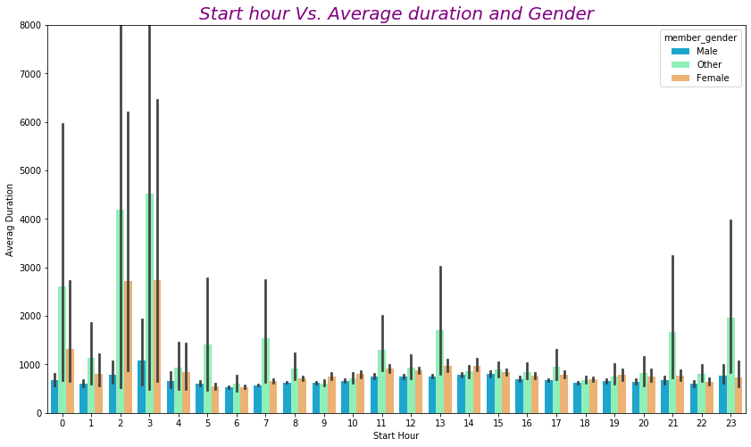

#### This plot assure that female and other type gender have the highest duration time. Moreover, starting hours around 2 and 3 Am has the most duration time , which in conclusion made it clear about that the gender who did the most duration actually fall in the same start hour zone of the most duration which we clarified before that most duration hourrs spent belongs to riders start the trip from 2 or 3 am and mostly done by other and female gender types.

##### Reassurance of Age, Gender and spent duration

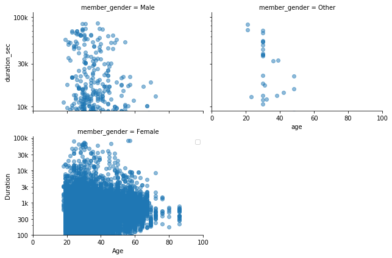

#### This 3 plots shows more density at upper left portion of female scatter plot than male, but it doesnt show it properly for other gender type due to the low count of pther in the data set but we did observed that other has the highest duration spent from barplots

##### Start Stations that riders start from and spend higher duration

[figure not shown]

##### Confirmation of Gender, User type, and duration relationship

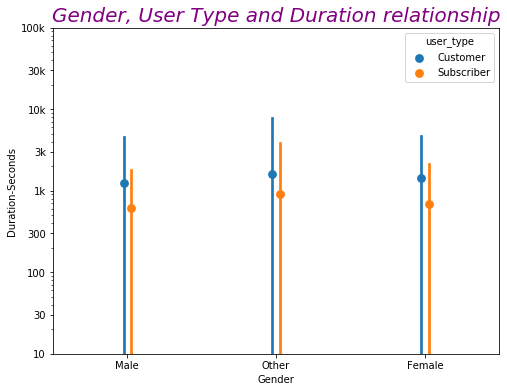

#### This plot assure that Customers made higher duration than subscribers and other type and females did higher duration than males

#### Confirmation of highest spent duration in certain days and certain start hours rides

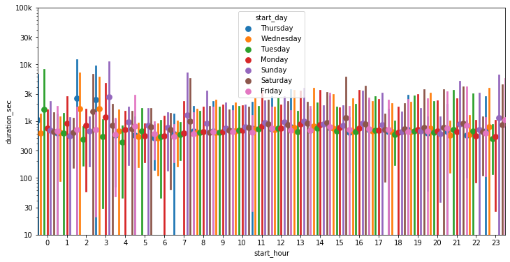

#### From this point plot we can see that Sunday, Saturday,Thursday, and Tuesday with starting hours (12,1,2,3,7,8) Am contributed with the highest duration spent, and all fall on the left portion of the plot in the early hours zone